# Práctica 4 PLN: pre-procesado de texto y extracción de características

En esta práctica vamos a realizar la limpieza y pre-procesado de distintos conjuntos de datos de texto.\ Luego haremos una extracción de características como matriz *sparse* y como vectores de palabras

### Nombres:

Introduce en esta celda los nombres de los dos integrantes del grupo:\ Yana Veitsman

## Parte 1: conjunto de textos de "mundocine"

En este primer conjunto de datos tenemos una serie de críticas de películas de cine, almacenadas en formato XML (una crítica por archivo). Hemos preparado una función de tipo `generator` que procesa el directorio donde están los archivos de las críticas y devuelve por cada archivo XML una tupla con 4 valores:

- Nombre de la película (*string*)
- Resumen breve de la crítica (*string*)
- Texto de la crítica (*string*)
- Valoración de la película (*int* de 1 a 5)

```python
import os, re
from xml.dom.minidom import parseString

def parse_folder(path):
    """generator that reads the contents of XML files in a folder
    Returns the <body> of the <review> in each XML file.
    XML files encoded as 'latin-1'"""
    for file in sorted([f for f in os.listdir(path) if f.endswith('.xml')],
                        key=lambda x: int(re.match(r'\d+',x).group())):
        with open(os.path.join(path, file), encoding='latin-1') as f:
            doc=parseString(f.read())

            titulo = doc.documentElement.attributes["title"].value

            btxt = ""
            review_bod = doc.getElementsByTagName("body")
            if len(review_bod) > 0:
                for node in review_bod[0].childNodes:
                    if node.nodeType == node.TEXT_NODE:
                        btxt += node.data + " "

            rtxt = ""
            review_summ = doc.getElementsByTagName("summary")
            if len(review_summ) > 0:
                for node in review_summ[0].childNodes:
                    if node.nodeType == node.TEXT_NODE:
                        rtxt += node.data + " "

            rank = int(doc.documentElement.attributes["rank"].value)

            yield titulo, rtxt, btxt, rank
```

### Ejercicio

Las críticas se encuentran en el directorio "criticas" (si no tienes el directorio, descomprime el archivo "criticas.zip" que se entrega en el material de la práctica. \ Carga la primera crítica del directorio usando el método `next` sobre la función `parse_folder` en el objeto `critica`. Muestra sus 4 valores.

```python
critica = next(parse_folder("C:\\Users\\Yana\\criticas"))
critica
```

```
('La guerra de los mundos',
 'Hasta los cojones de los yankis ',
 'Cada vez me gusta menos el cine de masas. Las peliculas que ven todo el mundo me parecen cada vez mas coñazo y mas insufribles. No se porqué pero siempre el prota es tonto del culo y tiene suerte, y al final de la peli, cuando ha logrado vencer al mal, se convierte en listo, y las chorradas que ha…
 1)
```

## Análisis exploratorio

Antes de procesar el texto vamos a calcular una serie de parámetros de cada crítica. \ Para eso procesamos cada crítica para y guardaremos los resultados en un objeto `DataFrame` de Pandas.\ Como característica de cada crítica vamos a extraer:

- Título de la película
- Longitud (en caracteres) del resumen
- Longitud (en caracteres) del texto de la crítica
- Puntuación de la crítica

### Ejercicio

Completa el código siguiente para generar el `DataFrame`

```python
import pandas as pd

#creamos una lista en blanco
datos = []

#recorremos las críticas y calculamos sus métricas
for c in parse_folder("C:\\Users\\Yana\\criticas"):
    datos.append({
        'título': c[0],
        'LongResumen': len(c[1]),
        'LongCritica': len(c[2]),
        'puntuación': c[3]
    })

resumen = pd.DataFrame(datos)
```

```python
resumen
```

|  | título | LongResumen | LongCritica | puntuación |
| --- | --- | --- | --- | --- |
| 0 | La guerra de los mundos | 32 | 2951 | 1 |
| 1 | Stars Wars III La venganza de los Sith | 30 | 3954 | 3 |
| 2 | Los Increibles | 68 | 2467 | 5 |
| 3 | Spiderman 2 | 45 | 3403 | 2 |
| 4 | La casa de cera | 42 | 1696 | 2 |
| 5 | El internado | 31 | 1163 | 2 |
| 6 | La llave del mal | 36 | 1781 | 3 |
| 7 | May | 28 | 3343 | 4 |
| 8 | Cinderella Man | 33 | 2885 | 2 |
| 9 | La Novia Cadaver | 40 | 736 | 3 |
| 10 | Harry poter y el caliz de fuego | 47 | 5127 | 4 |
| 11 | Match point | 19 | 2847 | 5 |
| 12 | King Kong | 12 | 2623 | 5 |
| 13 | El jardinero fiel | 43 | 2078 | 4 |
| 14 | Doom | 25 | 1790 | 3 |
| 15 | Las cronicas de Narnia | 55 | 1451 | 3 |
| 16 | Una historia violenta | 32 | 981 | 2 |
| 17 | Saw 2 | 50 | 3886 | 3 |
| 18 | Crash | 30 | 1478 | 3 |
| 19 | Jarhead | 69 | 3413 | 5 |
| 20 | Memorias de una Geisha | 71 | 2597 | 3 |
| 21 | Brokeback mountain | 70 | 5027 | 2 |
| 22 | Alone in the dark | 57 | 1519 | 1 |
| 23 | Munich | 45 | 4669 | 2 |
| 24 | Terror en la niebla | 37 | 4637 | 1 |
| 25 | Secretos de familia | 52 | 1541 | 2 |
| 26 | Underworld evolution | 75 | 1579 | 3 |
| 27 | Lutero | 69 | 3083 | 2 |
| 28 | Camaron | 22 | 1448 | 3 |

## Limpieza de texto

Vamos a preparar este conjunto de textos para entrenar un modelo para predecir la puntuación de cada crítica a partir del texto de la crítica.\ Realizaremos el siguiente procesado:

- Separar el texto en *tokens*
- Eliminar los *tokens* de tipo *stop-word*, signos de puntuación o espacios
- Convertir las entidades de tipo `PER` al token *persona*
- Lematizar el texto

### Ejercicio

Completa el código siguiente para realizar estas funciones:

```python
import spacy
from spacy.lang.en.stop_words import STOP_WORDS

# Decidí a usar isalpha() para eliminar signos de puntuación o espacios y la lista de STOP_WORDS de spacy para eliminar
# stop words

nlp = spacy.load("es_core_news_sm")

#definimos función de normalizado
def normaliza(texto):
    doc = nlp(texto)
    tokens = [t for t in doc if t.text.isalpha() and t not in STOP_WORDS]
    palabras = []
    for t in tokens:
        if t.ent_iob_=='B' and t.ent_type_=='PER':
            palabras.append('persona')
        elif t.ent_iob_=='I' and t.ent_type_=='PER':
            continue
        else:
            palabras.append(t.lemma_) #si no es PER añadimos el lema
    salida = " ".join(palabras)

    return salida
```

Comprueba su funcionamiento en la crítica previamente descargada (variable `critica`)

```python
normaliza(critica[2])
```

```
'Cada vez me gustar menos el cine de masa Las peliculas que ver todo el mundo me parecer cada vez mas coñazo y mas insufrible No se porqué pero siempre el prota ser tonto del culo y tener suerte y al final de lo peli cuando haber lograr vencer al mal se convertir en listar y los chorrada que hacia a…
```

### Posibles mejoras sobre el procesado

Observamos los siguientes problemas:

- Algunas palabras no se separan correctamente porque en el texto original están unidas por signos de puntuación.\
- La lista de *stop-words* de spaCy no contiene 'a','e','y'.\
- Algunos lemas mantienen las mayúsculas.\ Redefinimos la función de normalización para corregir esto:
- Introducimos un espacio después de determinados signos de puntuación (".", "?") para que el tokenizado sea correcto
- Filtramos los *tokens* con una longitud de 1
- Pasamos a minúsculas el lema de cada token

Completa la función para realizar estas correcciones:

```python
def normaliza_bis(texto):
    texto = re.sub(r"\.", r". ", texto)
    texto = re.sub(r"\?", r"? ", texto) #añadimos un espacio después de "." y "?"
    doc = nlp(texto)
    tokens = [t for t in doc if t.text.isalpha() and t not in STOP_WORDS and t.text not in ['a', 'y', 'e'] and len(t.text) > 1]
    palabras = []
    for t in tokens:
        if t.ent_iob_=='B' and t.ent_type_=='PER':
            palabras.append('persona')
        elif t.ent_iob_=='I' and t.ent_type_=='PER':
            continue
        else:
            palabras.append(t.lemma_.lower()) #añadimos lema en minúsculas
    salida = " ".join(palabras)

    return salida
```

Comprueba su funcionamiento en la crítica previamente descargada (variable `critica`)

```python
normaliza_bis(critica[2])
```

```
'cada vez me gustar menos el cine de masa las peliculas que ver todo el mundo me parecer cada vez mas coñazo mas insufrible no se porqué pero siempre el prota ser tonto del culo tener suerte al final de lo peli cuando haber lograr vencer al mal se convertir en listar los chorrada que hacia al comenz…
```

### Análisis morfológico

En una crítica tiene mucha importancia los adjetivos utilizados.\ Crea una función para filtrar sólo los adjetivos utilizados en cada crítica (utiliza el lema de cada adjetivo).

```python
def extraer_adj(texto):
    texto = re.sub(r"\.", r". ", texto)
    texto = re.sub(r"\?", r"? ", texto) #separamos . y ?
    doc = nlp(texto)
    tokens = [t.lemma_ for t in doc if t.pos_ == 'ADJ'] #obtenemos lema de todos los tokens de tipo ADJ
    return ' '.join(tokens)
```

Comprueba su funcionamiento en la crítica previamente descargada (variable `critica`)

```python
extraer_adj(critica[2])
```

```
'insufrible madurar inteligente solo echarles viejo meter original claro grande maduro horroroso asustar adolescente militar loco seguro viejo maquillar sinsorgada mejor igual misterio bueno especial dificiles peli estaria aceptable'
```

### Procesado de todo el conjunto de datos

Vamos a aplicar estas funciones en bloque a todo el conjunto de datos. \ En esta ocasión, no vamos a hacer nada con el texto normalizado sino que sólo lo vamos a aplicar para calcular el nº de palabras y el nº de adjetivos de cada crítica.

### Ejercicio

Completa el código siguiente:\ Nota: ten en cuenta que para contar palabras tienes que dividir el *string* en espacios y contar el nº de elementos

```python
#creamos una lista en blanco
datos = []

#recorremos las críticas y calculamos sus métricas
for c in parse_folder("criticas"):
    datos.append({
        'título': c[0],
        'LongResumen': c[1],
        'LongCritica': c[2],
        'NumPalabras': len(c[2].split()),
        'NumAdj': len(extraer_adj(c[2])),
        'puntuación': c[3]
    })

resumen = pd.DataFrame(datos)
resumen
```

|  | título | LongResumen | LongCritica | NumPalabras | NumAdj | puntuación |
| --- | --- | --- | --- | --- | --- | --- |
| 0 | La guerra de los mundos | Hasta los cojones de los yankis | Cada vez me gusta menos el cine de masas. Las ... | 568 | 231 | 1 |
| 1 | Stars Wars III La venganza de los Sith | La de los sits y el dar vader | El otro dia fui a ver "la de los sioux" como d... | 761 | 356 | 3 |
| 2 | Los Increibles | ¿Por qué las peliculas animadas son mucho mejo... | Es que no la cagan en ninguna, todas las pelis... | 462 | 265 | 5 |
| 3 | Spiderman 2 | Poniendo a parir una peli que no cuenta nada | Es un dolor esto del cine. Yo ya voy con miedo... | 651 | 260 | 2 |
| 4 | La casa de cera | Casquería, terror y cera a partes iguales | Tras una insufrible primera media hora, la cas... | 313 | 197 | 2 |
| 5 | El internado | Bodrio de terror a la francesa | Joder que bodrio de internado. La peli no empi... | 209 | 164 | 2 |
| 6 | La llave del mal | Da más miedo la factura de mi móvil | La llave del mal no es mala película, pero dec... | 318 | 216 | 3 |
| 7 | May | May, ¿quieres ser mi amigo? | "May, ¿Quieres ser mi amigo?" es una de esas p... | 564 | 487 | 4 |
| 8 | Cinderella Man | Cinta maniquea y mil veces vista | Cinderella Man es como comerse un Whopper con ... | 492 | 376 | 2 |
| 9 | La Novia Cadaver | Un calco de Pesadilla antes de Navidad. | Yo creía que iba a ver algo nuevo de Tim Burto... | 129 | 57 | 3 |
| 10 | Harry poter y el caliz de fuego | Interesante adaptación de la novela de Rowling | No. Esta vez no voy a usar una película como p... | 876 | 785 | 4 |
| 11 | Match point | Genial Woody Allen | Es sabido que retrata la burguesía como muy po... | 482 | 344 | 5 |
| 12 | King Kong | El rey Kong | El esfuerzo del director por hacer que esta pe... | 479 | 296 | 5 |
| 13 | El jardinero fiel | Tres buenos motivos para ver ésta película | "El jardinero fiel" se basa en el libro del mi... | 333 | 266 | 4 |
| 14 | Doom | Qué mala es la nostalgia | Ahora es cuando quedo como un friki al decir. ... | 317 | 152 | 3 |
| 15 | Las cronicas de Narnia | Buena, pero le falta algo para ser un clásico ... | Unos jovencitos llegan a un fantástico mundo l... | 251 | 211 | 3 |
| 16 | Una historia violenta | Una historia realmente violenta | Una Historia Violenta, 2005, es verdaderamente... | 163 | 114 | 2 |
| 17 | Saw 2 | Se queda algo lejos de lo que vimos en la prim... | Hace un año llegaba a la pantalla una novedosa... | 645 | 433 | 3 |
| 18 | Crash | ¿De qué pasta está uno hecho? | Cuando una encuesta quiere saber si un grupo e... | 260 | 150 | 3 |
| 19 | Jarhead | Una de las mejores películas anti-bélicas desd... | La última película de Sam Mendes (ganador del ... | 577 | 383 | 5 |
| 20 | Memorias de una Geisha | En realidad, es una historia de amor más que u... | El cine asiático se ha convertido ya en lo que... | 452 | 345 | 3 |
| 21 | Brokeback mountain | La película más sobrevalorada que ha dado el c... | Por fin he podido ver "Brokeback Mountain", la... | 852 | 631 | 2 |
| 22 | Alone in the dark | Efectillos especiales sin guión, y acción sin ... | Advertencia a todos mis lectores, no vayan al ... | 266 | 106 | 1 |
| 23 | Munich | Demasiado superficial, simplista y didáctica | La nueva película de Steven Spielberg es de es... | 746 | 702 | 2 |
| 24 | Terror en la niebla | Un enorme bodrio, lleno de tonterías | Otro remake americano que se estrena entre nos... | 826 | 548 | 1 |
| 25 | Secretos de familia | Por fin Rowan haciendo un papel distinto a Mr.... | Rowan Atkinson protagoniza esta comedia al más... | 271 | 214 | 2 |
| 26 | Underworld evolution | Si eres de los que disfrutaste con la primera ... | No entraremos mucho en detalles sobre el hilo ... | 277 | 189 | 3 |
| 27 | Lutero | Desde la más profunda indiferencia hasta el so... | Parece que, de un tiempo a aquí, el narrar la ... | 518 | 381 | 2 |
| 28 | Camaron | Me dió muy buen rollo | La película trata sobre la vida de Jose Monge,... | 262 | 135 | 3 |

## Parte 2: Extracción de características *sparse*

Vamos a calculas las matrices de características *bag-of-words* y *tfidf* del conjunto de textos anterior.\ Vamos a usar la librería `scikit-learn` para vectorizar los documentos.

```python
#Para no tener que cargar todas las críticas en memoria,
#creamos un generador que devuelve iterativamente el
#texto procesado de cada crítica

def generaCritica(criticas):
    """Función de tipo generator que devuelve el
    texto normalizado de cada crítica.
    Entrada:
    criticas: objeto 'parse_folder' que itera
    sobre el directio de las críticas
    Salida:
    texto normalizado de cada crítica"""
    for c in criticas:
        yield normaliza_bis(c[2])
```

Comprueba su funcionamiento generando el texto normalizado de la primera crítica

```python
next(generaCritica(parse_folder("C:\\Users\\Yana\\criticas")))
```

```
'cada vez me gustar menos el cine de masa las peliculas que ver todo el mundo me parecer cada vez mas coñazo mas insufrible no se porqué pero siempre el prota ser tonto del culo tener suerte al final de lo peli cuando haber lograr vencer al mal se convertir en listar los chorrada que hacia al comenz…
```

Vectorizamos todo el conjunto de datos usando las funciones de `scikit-learn`.\ Estas funciones admiten un objeto `generator` como argumento de entrada.

```python
from sklearn.feature_extraction.text import CountVectorizer

vect = CountVectorizer()
criticas = generaCritica(parse_folder("C:\\Users\\Yana\\criticas"))
BoW_criticas1 = vect.fit_transform(criticas)
BoW_criticas1
```

```
<29x2555 sparse matrix of type '<class 'numpy.int64'>'
	with 5968 stored elements in Compressed Sparse Row format>
```

### Ejercicio

Genera distintas variantes de matrices de características para el conjunto de las críticas. Prueba con:

- Matriz TF-IDF
- Matriz BoW con unigramas y bigramas
- Matriz TF-IDF eliminando las palabras menos frecuentes y las más frecuentes (mínimo de 2 y máximo de 5 documentos)
- Muestra cuáles son las palabras más frecuentes eliminadas

```python
#matriz TF-IDF
from sklearn.feature_extraction.text import TfidfVectorizer
vect = TfidfVectorizer()
criticas = generaCritica(parse_folder("C:\\Users\\Yana\\criticas"))
TF_IDF_criticas1 = vect.fit_transform(criticas)
TF_IDF_criticas1
```

```
<29x2555 sparse matrix of type '<class 'numpy.float64'>'
	with 5968 stored elements in Compressed Sparse Row format>
```

```python
#matriz BoW con unigramas y bigramas
vect = CountVectorizer(ngram_range = (1,2))
criticas = generaCritica(parse_folder("C:\\Users\\Yana\\criticas"))
BoW_criticas2 = vect.fit_transform(criticas)
BoW_criticas2
```

```
<29x11461 sparse matrix of type '<class 'numpy.int64'>'
	with 17331 stored elements in Compressed Sparse Row format>
```

```python
#matriz TF-IDF con min_df=1 y max_df=5
vect = TfidfVectorizer(min_df=1, max_df=5)
criticas = generaCritica(parse_folder("C:\\Users\\Yana\\criticas"))
TF_IDF_criticas2 = vect.fit_transform(criticas)
TF_IDF_criticas2
```

```
<29x2356 sparse matrix of type '<class 'numpy.float64'>'
	with 3482 stored elements in Compressed Sparse Row format>
```

```python
#palabras más frecuentes a eliminar
#aparecen en el atributo 'stop_words_' del vectorizador
vect = CountVectorizer(max_df=1)
criticas = generaCritica(parse_folder("C:\\Users\\Yana\\criticas"))
BoW_criticas3 = vect.fit(criticas)
BoW_criticas3.stop_words_
```

```
{'abrir',
 'absoluto',
 'absurdo',
 'aburrir',
 'acabar',
 'accion',
 'acción',
 'acontecimiento',
 'actitud',
 'actor',
 'actriz',
 'actuación',
 'actuar',
 'adaptación',
 'además',
 'adolescente',
 'adorar',
 'afirmar',
 'agradable',
 'agradecer',
 'aguantar',
 'ahi',
 'ahora',
 'ahí',
 'aire',
 'al',
 'alarde',
 'alejar',
 'algo',
 'alguien',
 'alguno',
 'aliviar',
 'allá',
 'alrededor',
 'alto',
 'amar',
 'ambientación',
 'ambientar',
 'american',
 'americano',
```

[output cut: 772 more lines]

```
 'viejo',
 'violencia',
 'visionar',
 'visual',
 'vivir',
 'volver',
 'vulnerable',
 'víctima',
 'víscera',
 'ya',
 'yo',
 'él',
 'época',
 'último',
 'único'}
```

## Word embeddings

Ahora vamos a calcular los *word vectors* de las palabras de nuestro conjunto de datos, usando la clase `word2vec` de la librería `gensim`.\ Esta librería acepta como argumento de entrada un objeto `iterador` que generará el texto pre-procesado de la siguiente crítica en la secuencia.\ Vamos a usar las funciones de pre-procesado de la librería `gensim`.\ Primero definimos un objeto de tipo `iterator` para recorrer las críticas. Se diferencia de un simple `generator` en que se puede reiniciar la generación de la secuencia (necesario para el modelo `word2vec`)

```python
from gensim.utils import simple_preprocess

class PreprocesaCriticas(object):
    """Pre-procesa el corpus de críticas con la función 'simple_preprocess'
    de la librería gensim
    Entrada: directorio de críticas
    Salida: iterador sobre las críticas (como lista de tokens)"""
    def __init__(self, dirname):
        self.dirname = dirname

    def __iter__(self):
        for c in parse_folder(self.dirname):
            yield simple_preprocess(c[2], deacc=True, min_len=2)
```

```python
#instanciamos un objeto para nuestro directorio
criticas = PreprocesaCriticas("C:\\Users\\Yana\\criticas")
```

Para probar su funcionamiento con la primera crítica lo convertimos en iterable y usamos el método `next`

```python
criticas.__iter__().__next__()
```

```
['cada',
 'vez',
 'me',
 'gusta',
 'menos',
 'el',
 'cine',
 'de',
 'masas',
 'las',
 'peliculas',
 'que',
 'ven',
 'todo',
 'el',
 'mundo',
 'me',
 'parecen',
 'cada',
 'vez',
 'mas',
 'conazo',
 'mas',
 'insufribles',
 'no',
 'se',
 'porque',
 'pero',
 'siempre',
 'el',
 'prota',
 'es',
 'tonto',
 'del',
 'culo',
 'tiene',
 'suerte',
 'al',
 'final',
 'de',
```

[output cut: 481 more lines]

```
 'hoy',
 'en',
 'dia',
 'no',
 'tener',
 'un',
 'mando',
 'con',
 'el',
 'forward',
 'en',
 'la',
 'mano',
 'es',
 'morir']
```

Al contrario que el objeto generado con la función `generaCriticas` el objeto de `PreprocesaCriticas` se reinicia cada vez que iteramos.

Calculamos los vectores de palabras de todo el corpus con el modelo `word2vec` que acepta como argumento de entrada un objeto de tipo `iterator` como el creado

```python
#Cálculo de los vectores de palabras
from gensim.models import Word2Vec

model = Word2Vec(criticas, #iterador con los documentos
                               size=10,          #tamaño del vector
                               window=5,         #nº de términos adyacentes que usamos para el cálculo
                               min_count=5,      #nº mínimo de apariciones del término para contarlo
                               iter=100
                              )

#una vez entrenado el modelo nos quedamos con los vectores calculados
#si no se van a actualizar los vectores con nuevos documentos
model = model.wv
len(model.vocab)
```

```
317
```

Seleccinamos aleatoriamente 25 palabras del conjunto calculado

```python
import numpy as np

palabras_sample = np.random.choice(model.index2word, 25, replace=False)
```

```python
palabras_sample
```

```
array(['uno', 'principio', 'nada', 'sino', 'momentos', 'film', 'ha',
       'casi', 'harry', 'solo', 'he', 'mejor', 'me', 'tambien', 'es',
       'mucha', 'mucho', 'los', 'aun', 'muestra', 'cual', 'protagonistas',
       'que', 'enemigo', 'son'], dtype='<U13')
```

### Ejercicio

Comprueba cómo funciona el modelo buscando las palabras más similares semánticamente a "trama", "peli" y "pelicula"

```python
#palabras similares a 'trama'
model.most_similar('trama')
```

```
[('quizas', 0.947236180305481),
 ('esa', 0.9409904479980469),
 ('hubiera', 0.8959928750991821),
 ('ritmo', 0.8610543608665466),
 ('personajes', 0.842481255531311),
 ('simplemente', 0.8236035704612732),
 ('cuenta', 0.8108744621276855),
 ('con', 0.8086515665054321),
 ('algunos', 0.8032928705215454),
 ('actores', 0.7789955735206604)]
```

```python
#palabras similares a 'peli'
model.most_similar('peli')
```

```
[('comienzo', 0.8818577527999878),
 ('mucha', 0.7942131161689758),
 ('dar', 0.7445759773254395),
 ('tiempo', 0.7229528427124023),
 ('cera', 0.7006334662437439),
 ('mal', 0.7002748847007751),
 ('casa', 0.6993142366409302),
 ('accion', 0.6898577213287354),
 ('dejar', 0.6850589513778687),
 ('ella', 0.6841527223587036)]
```

```python
#palabras similares a 'pelicula'
model.most_similar('pelicula')
```

```
[('mala', 0.8051681518554688),
 ('esto', 0.7561286091804504),
 ('sabido', 0.7430295944213867),
 ('pantalla', 0.7366597652435303),
 ('familia', 0.7313195466995239),
 ('antes', 0.7268853187561035),
 ('nina', 0.7225415110588074),
 ('consigue', 0.7217510938644409),
 ('me', 0.6976745128631592),
 ('es', 0.696481466293335)]
```

### Ejercicio

Vamos a ver la influencia del preprocesado. Para eso vamos a alimentar el modelo con las críticas preprocesadas con la función de normalización sobre `spaCy` (que produce texto lematizado y con otro filtrado).\ Para eso hay que re-definir el objeto iterador sobre el corpus.

```python
#comparamos con un modelo que use el preprocesado de spaCy
def normaliza_bis(texto):
    texto = re.sub(r"\.", r". ", texto)
    texto = re.sub(r"\?", r"? ", texto) #añadimos un espacio después de "." y "?"
    doc = nlp(texto)
    tokens = [t for t in doc if t.text.isalpha() and t not in STOP_WORDS and t.text not in ['a', 'y', 'e']]
    palabras = []
    for t in tokens:
        if t.ent_iob_=='B' and t.ent_type_=='PER':
            palabras.append('persona')
        elif t.ent_iob_=='I' and t.ent_type_=='PER':
            continue
        else:
            palabras.append(t.lemma_.lower()) #añadimos lema en minúsculas

    return palabras

class PreprocesaCriticasSpacy(object):
    """Pre-procesa el corpus de críticas con la función de normalización
    definida con la librería spaCy
    Entrada: directorio de críticas
    Salida: iterador sobre las críticas (como lista de tokens)"""
    def __init__(self, dirname):
        self.dirname = dirname

    def __iter__(self):
        for c in parse_folder(self.dirname):
            yield normaliza_bis(c[2])
```

### Ejercicio

Instancia esta nueva clase para el directorio de las críticas en el objeto `criticas_spacy` y comprueba su funcionamiento sobre la primera crítica

```python
criticas_spacy = PreprocesaCriticasSpacy("C:\\Users\\Yana\\criticas")
```

```python
#prueba a generar la primera crítica
criticas_spacy.__iter__().__next__()
```

```
['cada',
 'vez',
 'me',
 'gustar',
 'menos',
 'el',
 'cine',
 'de',
 'masa',
 'las',
 'peliculas',
 'que',
 'ver',
 'todo',
 'el',
 'mundo',
 'me',
 'parecer',
 'cada',
 'vez',
 'mas',
 'coñazo',
 'mas',
 'insufrible',
 'no',
 'se',
 'porqué',
 'pero',
 'siempre',
 'el',
 'prota',
 'ser',
 'tonto',
 'del',
 'culo',
 'tener',
 'suerte',
 'al',
 'final',
 'de',
```

[output cut: 481 more lines]

```
 'hoy',
 'en',
 'dia',
 'no',
 'tener',
 'uno',
 'mandar',
 'con',
 'el',
 'forward',
 'en',
 'lo',
 'manir',
 'ser',
 'morir']
```

Calcula el modelo de vectores de palabras con este nuevo pre-procesado

```python
modelSpacy = Word2Vec(criticas_spacy, #iterador con los documentos
                               size=10,          #tamaño del vector
                               window=5,         #nº de términos adyacentes que usamos para el cálculo
                               min_count=5,      #nº mínimo de apariciones del término para contarlo
                               iter=100
                              )

#una vez entrenado el modelo nos quedamos con los vectores calculados
#si no se van a actualizar los vectores con nuevos documentos
modelSpacy = modelSpacy.wv
len(modelSpacy.vocab)
```

```
343
```

### Respuesta

El tamaño es diferente porque hemos procesando diferentes stop words, puntuación y muchas cosas más que hemos apuntado en la función manualmente

### Visualización de word vectors

Usamos una reducción de dimensionalidad t-SNE para visualizar un grupo de palabras

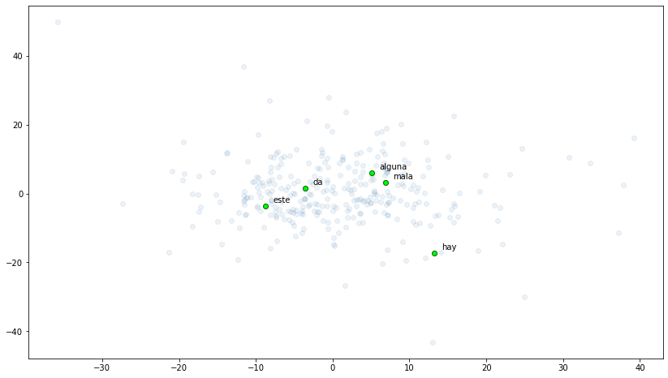

```python
from sklearn.manifold import TSNE
import matplotlib.pyplot as plt

palabras_vectors = model[model.index2word]

#seleccinamos unos pocos términos para visualizarlos entre el conjunto
random_idx = np.random.randint(len(model.index2word), size=5)

tsne = TSNE(n_components=2, random_state=0, n_iter=250, perplexity=2)
np.set_printoptions(suppress=True)
T = tsne.fit_transform(palabras_vectors)

plt.figure(figsize=(14, 8))
plt.scatter(T[:, 0], T[:, 1], c='steelblue', alpha=0.1)

labels = np.array(model.index2word)[random_idx]


T_labels = T[random_idx,:]

plt.scatter(T_labels[:, 0], T_labels[:, 1], c='lime', edgecolors='darkgreen')
for label, x, y in zip(labels, T_labels[:, 0], T_labels[:, 1]):
    plt.annotate(label, xy=(x+1, y+1), xytext=(0, 0), textcoords='offset points')
```

```python
labels
```

```
array(['este', 'mala', 'alguna', 'hay', 'da'], dtype='<U13')
```

Ahora vamos a cargar los vectores para las mismas palabras con el modelo pre-entrenado GloVe de spaCy para comparar

```python
palabras_vectors = [nlp.vocab[t].vector for t in model.index2word]

tsne = TSNE(n_components=2, random_state=0, n_iter=250, perplexity=2)
np.set_printoptions(suppress=True)
T = tsne.fit_transform(palabras_vectors)

plt.figure(figsize=(14, 8))
plt.scatter(T[:, 0], T[:, 1], c='steelblue', alpha=0.1)

labels = np.array(model.index2word)[random_idx]


T_labels = T[random_idx,:]

plt.scatter(T_labels[:, 0], T_labels[:, 1], c='lime', edgecolors='darkgreen')
for label, x, y in zip(labels, T_labels[:, 0], T_labels[:, 1]):
    plt.annotate(label, xy=(x+1, y+1), xytext=(0, 0), textcoords='offset points')
```

[output not shown]

## Parte 3: Conjunto de Tweets en español

Vamos a pre-procesar un conjunto de tweets en español etiquetados con su polaridad

```python
import pandas as pd

pd.set_option('display.max_colwidth', None)

# Leemos los datos
df = pd.read_csv('tweets_all.csv', index_col=None)

df.head()
```

|  | content | polarity |
| --- | --- | --- |
| 0 | -Me caes muy bien \n-Tienes que jugar más partidas al lol con Russel y conmigo\n-Por qué tan Otako, deja de ser otako\n-Haber si me muero | NONE |
| 1 | @myendlesshazza a. que puto mal escribo\n\nb. me sigo surrando help \n\n3. ha quedado raro el "cómetelo" ahí JAJAJAJA | N |
| 2 | @estherct209 jajajaja la tuya y la d mucha gente seguro!! Pero yo no puedo sin mi melena me muero | N |
| 3 | Quiero mogollón a @AlbaBenito99 pero sobretodo por lo rápido que contesta a los wasaps | P |
| 4 | Vale he visto la tia bebiendose su regla y me hs dado muchs grima | N |

### Ejercicio

Define una función de normalización que realice las siguientes tareas:

- Eliminar menciones y URL mediante un patrón RegEx
- Separar el texto en *tokens* convirtiéndolos a minúsculas, eliminando los que sean signos de puntuación, espacios o dígitos
- Eliminar los stop-words de una lista propia pasada como argumento
- Eliminar los símbolos de puntuación de los tokens (hashtags, admiraciones, etc.)
- Eliminar los tokens de una longitud menor de 2

```python
import string
import re
#lista de stop-words específicos de nuestro corpus (aproximación)
stop_words = ['los', 'pero', 'por', 'que', 'una']
url_patron = r"(http|https)://([\w_-]+(?:(?:\.[\w_-]+)+))([\w.,@?^=%&:/~+#-]*[\w@?^=%&/~+#-])?" # he encontrado online

patron = re.compile('[{}]'.format(re.escape(string.punctuation))) #elimina símbolos de puntuación

def clean_text(text, stop_words=stop_words):
    """Limpiamos las menciones y URL del texto. Luego convertimos en tokens
    y eliminamos signos de puntuación.
    Dejamos tokens en minúsculas.
    Como salida volvemos a convertir los tokens en cadena de texto"""
    text = re.sub(r"@\w+", r"", text)
    text = re.sub(url_patron, r"", text) #elimina menciones y URL
    tokens = nlp(text)
    tokens = [t for t in tokens if not (t.text.isdigit()) and not (t.text==' ') and not (bool(re.search(patron, t.text)))] #filtra tokens (puntuaciones, espacios y dígitos)
    filtered_tokens = [t.text.lower() for t in tokens if len(t.text) >= 2 and t.text not in stop_words] #limpia tokens (signos de puntuación, stop-words y longitud<2)
    filtered_text = " ".join(filtered_tokens) #juntamos como string
    return filtered_text
```

Aplica la función a todos los tweets (columna 'content') creando una nueva columna 'limpio' del dataframe

```python
limpios = []
for i in df['content']:
    limpios.append(clean_text(i))
df['limpio'] = limpios
```

```python
df.head()
```

|  | content | polarity | limpio |
| --- | --- | --- | --- |
| 0 | -Me caes muy bien \n-Tienes que jugar más partidas al lol con Russel y conmigo\n-Por qué tan Otako, deja de ser otako\n-Haber si me muero | NONE | caes muy bien jugar más partidas al lol con russel conmigo qué tan otako deja de ser otako si me muero |
| 1 | @myendlesshazza a. que puto mal escribo\n\nb. me sigo surrando help \n\n3. ha quedado raro el "cómetelo" ahí JAJAJAJA | N | puto mal escribo \n\n me sigo surrando help \n\n ha quedado raro el cómetelo ahí jajajaja |
| 2 | @estherct209 jajajaja la tuya y la d mucha gente seguro!! Pero yo no puedo sin mi melena me muero | N | jajajaja la tuya la mucha gente seguro pero yo no puedo sin mi melena me muero |
| 3 | Quiero mogollón a @AlbaBenito99 pero sobretodo por lo rápido que contesta a los wasaps | P | quiero mogollón sobretodo lo rápido contesta wasaps |
| 4 | Vale he visto la tia bebiendose su regla y me hs dado muchs grima | N | vale he visto la tia bebiendose su regla me hs dado muchs grima |